# Tutorial 3 - Visualise data with `ggplot2`

Author: Matthew J. Cossley

Last update: 12 March, 2022

## Learning objectives

- Get lots of hands-on practice with `R` and `data.table` and `ggplot`.
- In particular, practice using the following functions:
  - `ggplot()`
  - `geom_point()`
  - `geom_line()`
  - `geom_bar()`
  - `geom_hist()`
  - `geom_violin()`
  - `geom_boxplot()`

## Do the following tutorials

- [Intro](https://tutorials.shinyapps.io/02-Vis-Basics/)
- [Bar charts](https://rstudio.cloud/learn/primers/3.2)
  - Sections: Bar Charts (excluding Exercise 4) and Facets
- [Histograms](https://rstudio.cloud/learn/primers/3.3)
  - Sections: Histograms
- [Boxplots](https://rstudio.cloud/learn/primers/3.4)
  - Sections: Boxplots (excluding cut functions) and Similar Geoms
- [Scatterplots](https://rstudio.cloud/learn/primers/3.5)
  - Sections: Layers (only Code duplication onwards)
- [Line plots](https://rstudio.cloud/learn/primers/3.6)
  - Sections: Line graphs
- [Customize](https://rstudio.cloud/learn/primers/3.8)
  - Sections: Labels and Themes
- Finally, a nice ggplot cheat sheet can be downloaded [here](https://raw.githubusercontent.com/rstudio/cheatsheets/main/data-visualization.pdf)

Please note that you may encounter some non-`data.table` code here and there in these tutorials. Please do your best to ignore it and focus on the `ggplot` aspects of the lessons. The non-`data.table` aspects that you run into won’t be how we prefer to do things in this unit, and your tutor will help you identify what is relevant and what isn’t. Be sure to ask if you are unsure.

Please also note that the above tutorials are to be interacted with completely within a web browser. You will not need to use R Studio in this part of today’s tutorial.

## Get some experiment data

- Complete the experiment located at the following address: `https://run.pavlovia.org/demos/stroop/`
- Be sure to enter your name or some other ID that you will remember and can be easily searched for.
- Download your data in a `.csv` file by taking the following steps:
- Go here: `https://gitlab.pavlovia.org/demos/stroop`
- Read about the experiment you just participated in by scrolling to the bottom and reading the `README.md` file.
- Click the `data` folder to land at the following address: `https://gitlab.pavlovia.org/demos/stroop/tree/master/data`
- Near the top right of the page, click the `Find file` button, and search for a file containing the unique ID that you entered at the beginning of the experiment.
- Click on the `.csv` file that pops up.
- Finally, click the `download` button to download your `.csv` file to your local machine.

## Get ready to analyse your data

- If you haven’t done so already, create a new folder on your computer named `cogs2020`
- Open Rstudio and click `File > New File > R Script`
- In Rstudio click `File > Save`
- In the prompt that comes up, name your file `tutorial_3_notes.R`, and save it in your `cogs2020` folder.
- Move the `.csv` file you just downloaded into your `cogs2020` folder.

## Analyse your data using `data.table`

- Load the `data.table` library and `rm` to be sure your are starting with a clean work space.

```r
library(data.table)
library(ggplot2)

rm(list = ls())
```

- Load the data into a `data.table` using the `fread()` function from the `data.table` library.

```r
# my data lives within a subfolder named `data` so I need
# the following:
d <- fread('./data/data_mjc_stroop_2022-02-08_06h43.13.csv')

# If your data lives in the same directory as your code,
# then you would use:
# d <- fread('data_mjc_stroop_2022-02-08_06h43.13.csv')
```

```r
d[, .(text, letterColor, congruent, corrAns, resp.keys, resp.rt)]
```

```
##      text letterColor congruent corrAns resp.keys resp.rt
##  1: green       green         1    down      down   2.436
##  2:   red       green         0    down      down   2.069
##  3:   red         red         1    left      left   1.503
##  4: green        blue         0   right     right   2.717
##  5:  blue        blue         1   right     right   1.280
##  6:  blue         red         0    left      down   1.522
##  7: green        blue         0   right     right   0.803
##  8: green       green         1    down      left   1.021
##  9:   red         red         1    left     right   1.235
## 10:  blue         red         0    left     right   1.162
## 11:  blue        blue         1   right      down   0.748
## 12:   red       green         0    down      left   0.663
```

- The classic Stroop finding is that people are slower and less accurate on incongruent trials (i.e., trials on which stimulus text and stimulus colour do not match) than they are on congruent trials. Lets see if our data pan out that way.

```r
# first create a column to indicate response accuracy
d[, acc := corrAns == resp.keys]

# report what your overall accuracy was grouped by congruent
d[, mean(acc), .(congruent)]
```

```
##    congruent  V1
## 1:         1 0.5
## 2:         0 0.5
```

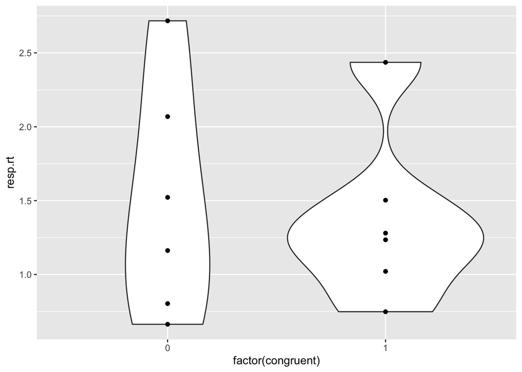

```r
# inspect reaction time
ggplot(d, aes(x=factor(congruent), y=resp.rt)) +
  geom_violin() +
  geom_point()
```

- Visualise this data in as many other ways as you can. Try to use all the function listed in the learning objectives.

## Work on problem set 3

- Problem set 3